# GDP y salario en Oro

Me quedo con el **GDP** y el **Salario**, lo normalizo para que este expresado en **oro**

```r
library(tidyverse)
library(lubridate)
library(forecast)
library(magrittr)
library(broom)
library(sweep)
library(ggthemes)
```

```r
gold <- read_csv("data/GOLD_1791-2018.csv",skip = 3)
gdp <- read_csv("data/USGDP_1790-2018.csv", skip=2)
wage <- read_csv("data/USWAGE_1774-2018.csv", skip=3)
gdp_in_gold <- left_join(gold, gdp, by = "Year") %>%
  transmute(value = `Nominal GDP per capita (current dollars)`/`New York Market Price (U.S. dollars per fine ounce)`,
         year = parse_date_time(Year,"y"))
wg_in_gold <- wage %>%
  #filter(Year>=1900) %>%
  left_join(gold, gdp, by = "Year") %>%
  transmute(value =`Production Workers Hourly Compensation (nominal dollars)`/`New York Market Price (U.S. dollars per fine ounce)`,
            year = parse_date_time(Year,"y")) %>%
  na.omit()
#lo paso a serie de tiempo
wg_in_gold$value <- ts(wg_in_gold$value,start = min(year(wg_in_gold$year)))
gdp_in_gold$value <- ts(gdp_in_gold$value,start = min(year(gdp_in_gold$year)))
```

```r
range(gdp_in_gold$year)
```

```
[1] "1791-01-01 UTC" "2017-01-01 UTC"
```

```r
range(wg_in_gold$year)
```

```
[1] "1791-01-01 UTC" "2017-01-01 UTC"
```

Agrupo las series antes y después de 1971

```r
df <- wg_in_gold %>%
  mutate(tipo = "wage") %>%
  bind_rows(gdp_in_gold %>%
              mutate(tipo = "gdp")) %>%
    mutate(group=case_when(year< parse_date_time(1971,orders = 'y')~"Antes del 71'",
                         TRUE ~ "Despues del 71'"))
```

```
Vectorizing 'ts' elements may not preserve their attributesVectorizing 'ts' elements may not preserve their attributes
```

## Autocorrelación, todo el período

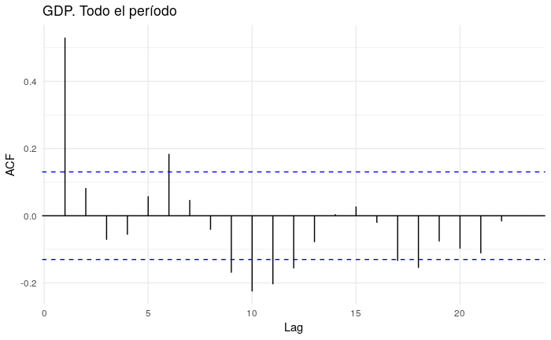

```r
ggAcf(diff(df %>%
             filter(tipo=="gdp") %$% value ))+
  labs(title= "GDP. Todo el período")+
  theme_minimal()
ggsave("plots/Autocorrelacion_gdp.png",dpi=300)
```

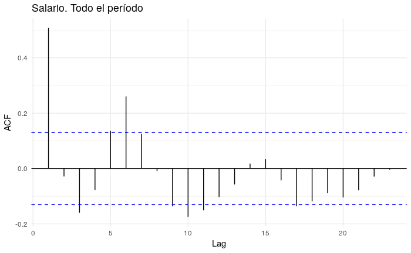

```r
ggAcf(diff(df %>%
             filter(tipo=="wage") %$% value ))+
  labs(title= "Salario. Todo el período")+
  theme_minimal()
ggsave("plots/Autocorrelacion_wg.png",dpi=300)
```

#### GDP

la serie en diferencias tiene una autocorrelación importante con el primer lag (tipo random walk) y una correlación negativa con 10 años atrás.

#### Salarios

Con la serie entera, además del período anterior, tiene una relación positiva con lo que sucede 6 años atrás (ídem GDP)

## Antes y después del 71

```r
diferencio <- function(df){diff(df$value)}
nested_df <- df %>%
  group_by(tipo,group) %>%
  nest() %>%
  mutate(diferencias  = map(data,diferencio))

nested_df
```

| tipo | group | data | diferencias |
| --- | --- | --- | --- |
| wage | Antes del 71' |  |  |
| wage | Despues del 71' |  |  |
| gdp | Antes del 71' |  |  |
| gdp | Despues del 71' |  |  |

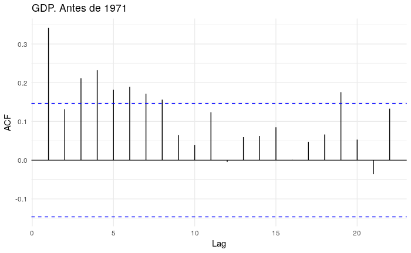

```r
nested_df %>%
  filter(tipo == "gdp", group=="Antes del 71'") %$%
  ggAcf(diferencias[[1]])+
  labs(title = "GDP. Antes de 1971")+
  theme_minimal()
ggsave("plots/Autocorrelacion_gdp_pre71.png",dpi=300)
```

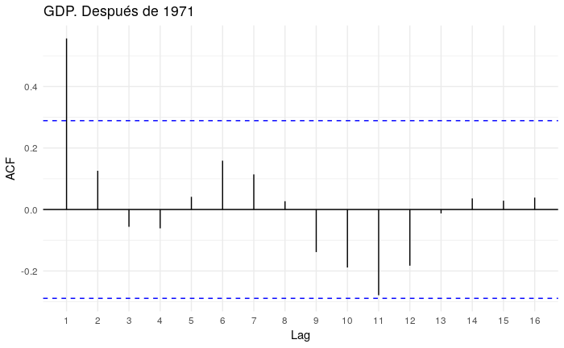

```r
nested_df %>%
  filter(tipo == "gdp", group=="Despues del 71'") %$%
  ggAcf(diferencias[[1]])+
  labs(title = "GDP. Después de 1971")+
  theme_minimal()
ggsave("plots/Autocorrelacion_gdp_post71.png",dpi=300)
```

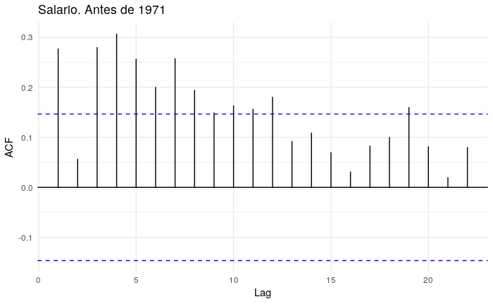

```r
nested_df %>%
  filter(tipo == "wage", group=="Antes del 71'") %$%
  ggAcf(diferencias[[1]])+
  labs(title = "Salario. Antes de 1971")+
  theme_minimal()
ggsave("plots/Autocorrelacion_wg_pre71.png",dpi=300)
```

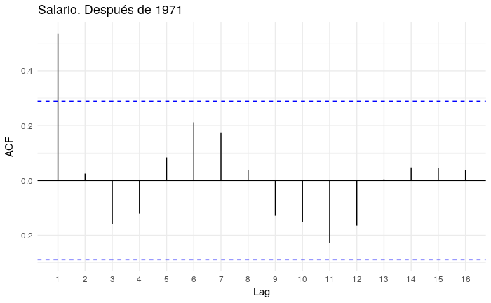

```r
nested_df %>%
  filter(tipo == "wage", group=="Despues del 71'") %$%
  ggAcf(diferencias[[1]])+
  labs(title = "Salario. Después de 1971")+
  theme_minimal()
ggsave("plots/Autocorrelacion_wg_post71.png",dpi=300)
```

**GDP**: Es como si con el patrón oro se pudiera ver una autocorrealción para el ciclo corto (3-5 años, *real business cycle*) pero a partir de los 70 es un Random Walk

## Arima

```r
fit.arima <- function(df,order){
  Arima(df$value, order = order)
}
nested_df <- nested_df %>%
  group_by(tipo, group) %>%
  mutate(fitted_arima_2_1_0 = map(data,fit.arima, order=c(2,1,0)),
         fitted_arima_5_1_0 = map(data,fit.arima, order=c(5,1,0)),
         fitted_arima_10_1_0 = map(data,fit.arima, order=c(10,1,0)),
         fitted_arima_1_1_1 = map(data,fit.arima, order=c(1,1,1)))
nested_df <- nested_df %>%
  mutate(tdy_2_1_0 = map(fitted_arima_2_1_0,sw_tidy),
         tdy_5_1_0 = map(fitted_arima_5_1_0,sw_tidy),
         tdy_10_1_0 = map(fitted_arima_10_1_0,sw_tidy),
         tdy_1_1_1 = map(fitted_arima_1_1_1,sw_tidy))

nested_df %>%
unnest(tdy_2_1_0, .drop=TRUE)
```

| tipo | group | term | estimate |
| --- | --- | --- | --- |
| wage | Antes del 71' | ar1 | 0.73429714 |
| wage | Antes del 71' | ar2 | -0.21486786 |
| wage | Despues del 71' | ar1 | 0.82303229 |
| wage | Despues del 71' | ar2 | -0.39570916 |
| gdp | Antes del 71' | ar1 | 0.58730575 |
| gdp | Antes del 71' | ar2 | -0.04136009 |
| gdp | Despues del 71' | ar1 | 0.76480629 |
| gdp | Despues del 71' | ar2 | -0.25757297 |

```r
nested_df %>%
unnest(tdy_5_1_0, .drop=TRUE)
```

| tipo | group | term | estimate |
| --- | --- | --- | --- |
| wage | Antes del 71' | ar1 | 0.55224712 |
| wage | Antes del 71' | ar2 | -0.57823243 |
| wage | Antes del 71' | ar3 | 0.49716105 |
| wage | Antes del 71' | ar4 | 0.23593182 |
| wage | Antes del 71' | ar5 | 0.16554733 |
| wage | Despues del 71' | ar1 | 0.83828931 |
| wage | Despues del 71' | ar2 | -0.48113355 |
| wage | Despues del 71' | ar3 | 0.16890824 |
| wage | Despues del 71' | ar4 | -0.25039059 |
| wage | Despues del 71' | ar5 | 0.29710924 |

[output cut: 10 more lines]

```r
nested_df %>%
unnest(tdy_10_1_0, .drop=TRUE)
```

| tipo | group | term | estimate |
| --- | --- | --- | --- |
| wage | Antes del 71' | ar1 | 0.55922029 |
| wage | Antes del 71' | ar2 | -0.63926201 |
| wage | Antes del 71' | ar3 | 0.40221864 |
| wage | Antes del 71' | ar4 | 0.25494587 |
| wage | Antes del 71' | ar5 | 0.09382973 |
| wage | Antes del 71' | ar6 | 0.02220717 |
| wage | Antes del 71' | ar7 | 0.32614085 |
| wage | Antes del 71' | ar8 | -0.17375669 |
| wage | Antes del 71' | ar9 | 0.13824025 |
| wage | Antes del 71' | ar10 | -0.06009755 |

[output cut: 30 more lines]

```r
nested_df %>%
unnest(tdy_1_1_1, .drop=TRUE)
```

| tipo | group | term | estimate |
| --- | --- | --- | --- |
| wage | Antes del 71' | ar1 | 0.1806573 |
| wage | Antes del 71' | ma1 | 0.6347339 |
| wage | Despues del 71' | ar1 | 0.3485695 |
| wage | Despues del 71' | ma1 | 0.5070144 |
| gdp | Antes del 71' | ar1 | 0.4204782 |
| gdp | Antes del 71' | ma1 | 0.1985021 |
| gdp | Despues del 71' | ar1 | 0.4213428 |
| gdp | Despues del 71' | ma1 | 0.3470247 |

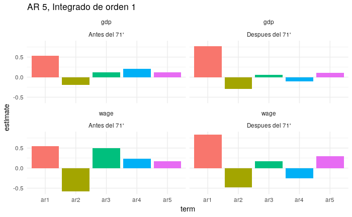

```r
nested_df %>%
unnest(tdy_5_1_0, .drop=TRUE) %>%
  ggplot(.,aes(term,estimate, fill= term))+
  geom_col()+
  facet_wrap(tipo~group)+
  theme_minimal()+
  theme(legend.position = "none")+
  labs(title = "AR 5, Integrado de orden 1")
```

```r
glances <- nested_df %>%
  mutate(g1 = map(fitted_arima_2_1_0,sw_glance),
         g2 = map(fitted_arima_5_1_0,sw_glance),
         g3 = map(fitted_arima_10_1_0,sw_glance),
         g4 = map(fitted_arima_1_1_1,sw_glance)) %>%
  select(tipo, group, g1, g2,g3,g4) %>%
  gather(model, glance, 3:6) %>%
  unnest(glance, .drop = TRUE)
glances
```

| tipo | group | model | model.desc | sigma | logLik | AIC | BIC | ME | RMSE | MAE | MPE | MAPE | MASE | ACF1 |
| --- | --- | --- | --- | --- | --- | --- | --- | --- | --- | --- | --- | --- | --- | --- |
| wage | Antes del 71' | g1 | ARIMA(2,1,0) | 0.001790983 | 878.9143 | -1751.8287 | -1742.2665 | 0.0003382776 | 0.001775996 | 0.0007606469 | 1.0601005 | 6.740593 | 0.8572297 | 0.042883462 |
| wage | Despues del 71' | g1 | ARIMA(2,1,0) | 0.006424577 | 167.5581 | -329.1163 | -323.6303 | -0.0008990777 | 0.006216157 | 0.0045570414 | -2.0234039 | 12.520318 | 0.7574341 | -0.063041873 |
| gdp | Antes del 71' | g1 | ARIMA(2,1,0) | 2.611650816 | -425.0144 | 856.0287 | 865.5909 | 0.4246723721 | 2.589795613 | 1.3181299050 | 1.0237236 | 6.238798 | 0.8826378 | -0.009597305 |
| gdp | Despues del 71' | g1 | ARIMA(2,1,0) | 9.700889312 | -169.0702 | 344.1405 | 349.6264 | -0.8340713553 | 9.386181731 | 6.9120705633 | -1.0896380 | 12.439013 | 0.7249882 | -0.049897053 |
| wage | Antes del 71' | g2 | ARIMA(5,1,0) | 0.001543966 | 905.7384 | -1799.4767 | -1780.3524 | 0.0001559195 | 0.001518015 | 0.0007554564 | 0.4499641 | 8.135981 | 0.8513802 | -0.015834387 |
| wage | Despues del 71' | g2 | ARIMA(5,1,0) | 0.006388181 | 169.1737 | -326.3474 | -315.3756 | -0.0006094021 | 0.005966508 | 0.0047341297 | -0.7849575 | 12.715846 | 0.7868683 | -0.088296917 |
| gdp | Antes del 71' | g2 | ARIMA(5,1,0) | 2.507923733 | -416.5579 | 845.1158 | 864.2402 | 0.2685677123 | 2.465770752 | 1.3213504727 | 0.6902781 | 6.509551 | 0.8847943 | -0.017855885 |
| gdp | Despues del 71' | g2 | ARIMA(5,1,0) | 9.987066696 | -168.8166 | 349.6331 | 360.6050 | -0.7126492807 | 9.327837027 | 7.0047754981 | -0.6916754 | 12.307455 | 0.7347117 | -0.069168814 |
| wage | Antes del 71' | g3 | ARIMA(10,1,0) | 0.001523933 | 910.3037 | -1798.6074 | -1763.5461 | 0.0001421965 | 0.001476634 | 0.0007623139 | 0.3744735 | 8.721098 | 0.8591085 | -0.001428331 |
| wage | Despues del 71' | g3 | ARIMA(10,1,0) | 0.006465712 | 170.9507 | -319.9014 | -299.7863 | -0.0006987417 | 0.005658726 | 0.0043651472 | -1.1286058 | 11.652591 | 0.7255390 | -0.057529149 |

[output cut: 6 more lines]

El **sigma** es la raíz de la variabilidad estimada de los residuos. Puedo comparar por serie

[MASE](https://en.wikipedia.org/wiki/Mean_absolute_scaled_error)

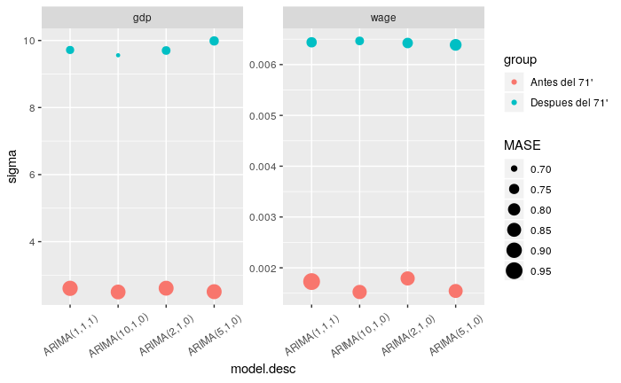

```r
ggplot(glances,aes(x=model.desc,y= sigma, color =group, size=MASE))+
geom_point()+
facet_wrap(tipo~., scales="free")+
theme(axis.text.x = element_text(angle=35, vjust = 0.5))
```

### chequeo unit roots

ARIMA(2,1,0)

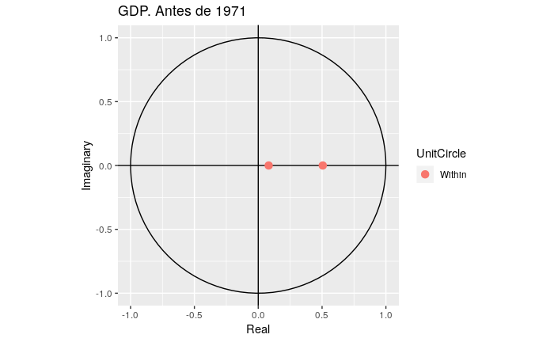

```r
nested_df %>%
  filter(tipo == "gdp", group=="Antes del 71'") %$%
  autoplot(fitted_arima_2_1_0[[1]])+
  labs(title = "GDP. Antes de 1971")
```

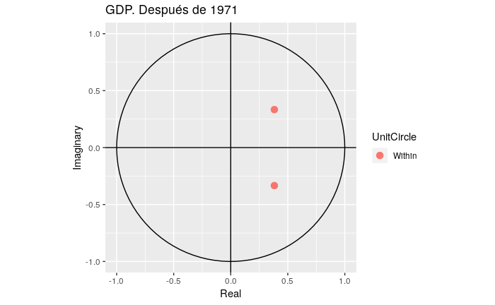

```r
nested_df %>%
  filter(tipo == "gdp", group=="Despues del 71'") %$%
  autoplot(fitted_arima_2_1_0[[1]])+
  labs(title = "GDP. Después de 1971")
```

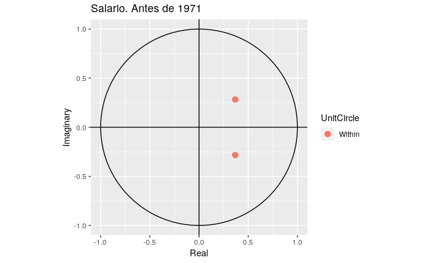

```r
nested_df %>%
  filter(tipo == "wage", group=="Antes del 71'") %$%
  autoplot(fitted_arima_2_1_0[[1]])+
  labs(title = "Salario. Antes de 1971")
```

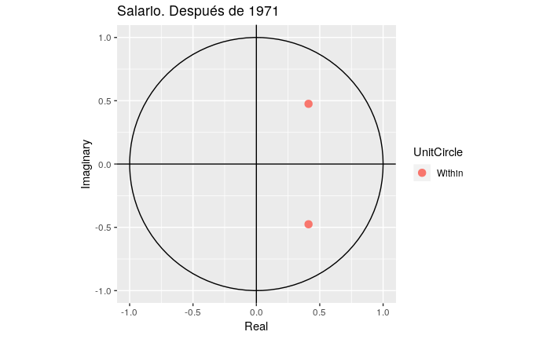

```r
nested_df %>%
  filter(tipo == "wage", group=="Despues del 71'") %$%
  autoplot(fitted_arima_2_1_0[[1]])+
  labs(title = "Salario. Después de 1971")
```

ARIMA(5,1,0)

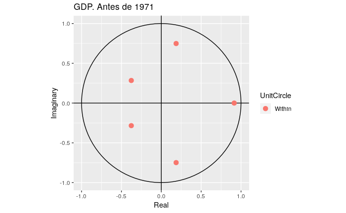

```r
nested_df %>%
  filter(tipo == "gdp", group=="Antes del 71'") %$%
  autoplot(fitted_arima_5_1_0[[1]])+
  labs(title = "GDP. Antes de 1971")
```

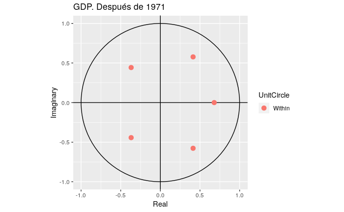

```r
nested_df %>%
  filter(tipo == "gdp", group=="Despues del 71'") %$%
  autoplot(fitted_arima_5_1_0[[1]])+
  labs(title = "GDP. Después de 1971")
```

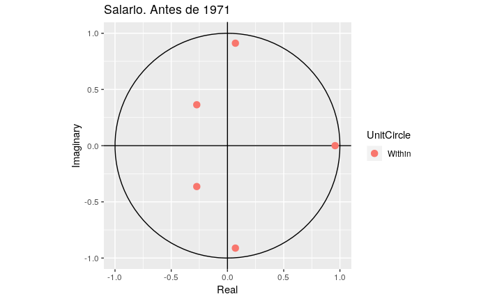

```r
nested_df %>%
  filter(tipo == "wage", group=="Antes del 71'") %$%
  autoplot(fitted_arima_5_1_0[[1]])+
  labs(title = "Salario. Antes de 1971")
```

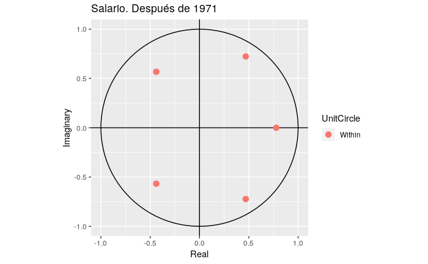

```r
nested_df %>%
  filter(tipo == "wage", group=="Despues del 71'") %$%
  autoplot(fitted_arima_5_1_0[[1]])+
  labs(title = "Salario. Después de 1971")
```

ARIMA(10,1,0)

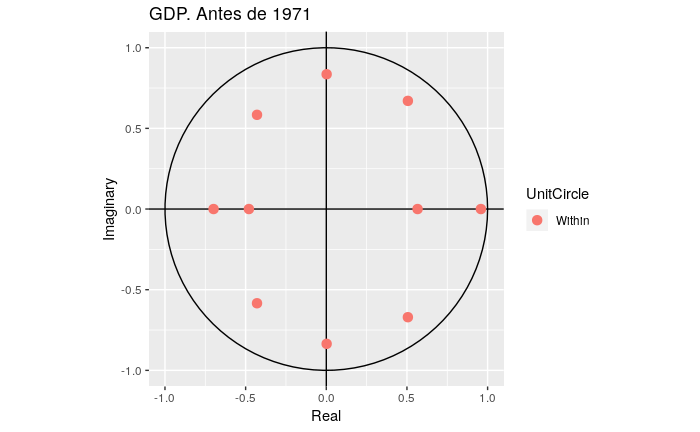

```r
nested_df %>%
  filter(tipo == "gdp", group=="Antes del 71'") %$%
  autoplot(fitted_arima_10_1_0[[1]])+
  labs(title = "GDP. Antes de 1971")
```

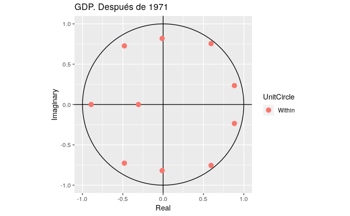

```r
nested_df %>%
  filter(tipo == "gdp", group=="Despues del 71'") %$%
  autoplot(fitted_arima_10_1_0[[1]])+
  labs(title = "GDP. Después de 1971")
```

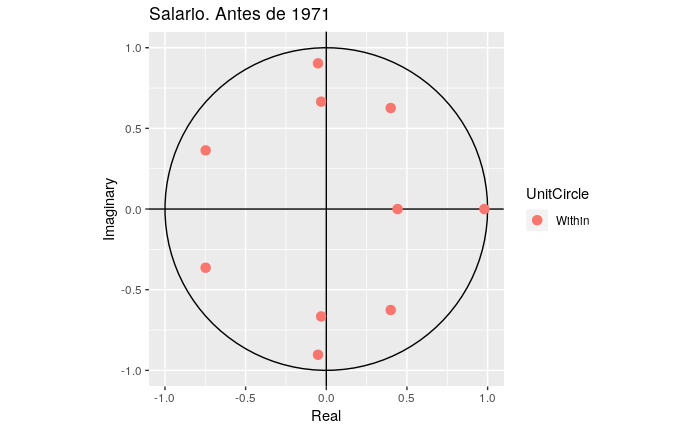

```r
nested_df %>%
  filter(tipo == "wage", group=="Antes del 71'") %$%
  autoplot(fitted_arima_10_1_0[[1]])+
  labs(title = "Salario. Antes de 1971")
```

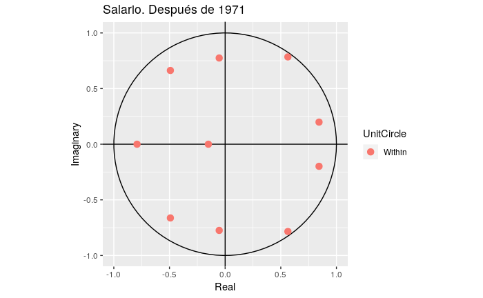

```r
nested_df %>%
  filter(tipo == "wage", group=="Despues del 71'") %$%
  autoplot(fitted_arima_10_1_0[[1]])+
  labs(title = "Salario. Después de 1971")
```

ARIMA(1,1,1)

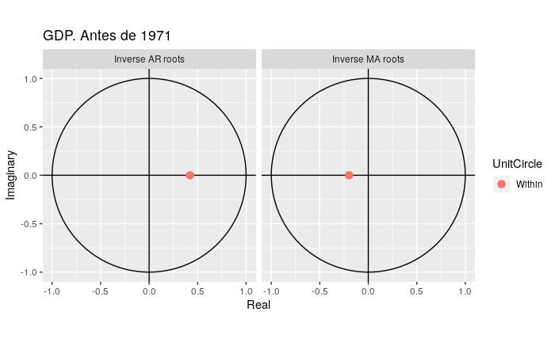

```r
nested_df %>%
  filter(tipo == "gdp", group=="Antes del 71'") %$%
  autoplot(fitted_arima_1_1_1[[1]])+
  labs(title = "GDP. Antes de 1971")
```

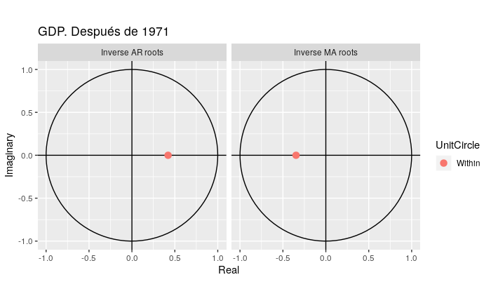

```r
nested_df %>%
  filter(tipo == "gdp", group=="Despues del 71'") %$%
  autoplot(fitted_arima_1_1_1[[1]])+
  labs(title = "GDP. Después de 1971")
```

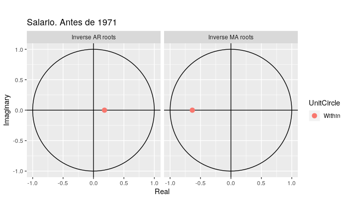

```r
nested_df %>%
  filter(tipo == "wage", group=="Antes del 71'") %$%
  autoplot(fitted_arima_1_1_1[[1]])+
  labs(title = "Salario. Antes de 1971")
```

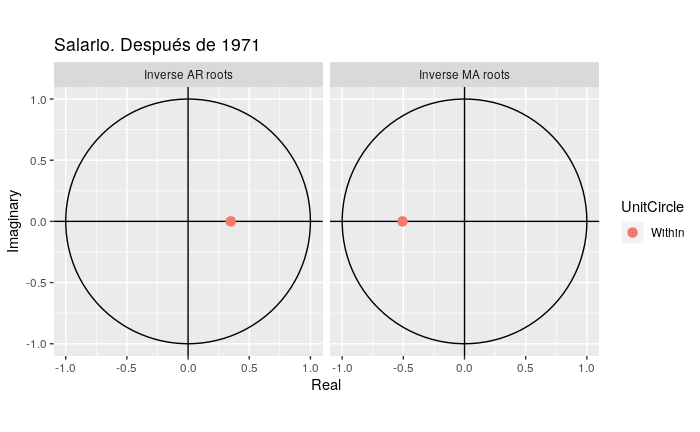

```r
nested_df %>%
  filter(tipo == "wage", group=="Despues del 71'") %$%
  autoplot(fitted_arima_1_1_1[[1]])+
  labs(title = "Salario. Después de 1971")
```

TODO adentro del circulo unitario

quiero ver cómo quedan los suavizados

```r
nested_df %>%
  mutate(augment = map(fitted_arima_2_1_0,sw_augment)) %>%
  unnest(augment, .drop = TRUE)
```

| tipo | group | index | .actual | .fitted | .resid |
| --- | --- | --- | --- | --- | --- |
| wage | Antes del 71' | 1 | 1.031460e-03 | 1.030428e-03 | 1.031459e-06 |
| wage | Antes del 71' | 2 | 1.031460e-03 | 1.031460e-03 | -8.012805e-10 |
| wage | Antes del 71' | 3 | 1.547189e-03 | 1.043505e-03 | 5.036842e-04 |
| wage | Antes del 71' | 4 | 1.547189e-03 | 1.925888e-03 | -3.786989e-04 |
| wage | Antes del 71' | 5 | 1.547189e-03 | 1.436376e-03 | 1.108138e-04 |
| wage | Antes del 71' | 6 | 2.062919e-03 | 1.547189e-03 | 5.157298e-04 |
| wage | Antes del 71' | 7 | 1.547189e-03 | 2.441618e-03 | -8.944286e-04 |
| wage | Antes del 71' | 8 | 2.062919e-03 | 1.057677e-03 | 1.005242e-03 |
| wage | Antes del 71' | 9 | 2.062919e-03 | 2.552432e-03 | -4.895126e-04 |
| wage | Antes del 71' | 10 | 2.062919e-03 | 1.952105e-03 | 1.108138e-04 |

[output cut: 444 more lines]

```r
nested_df %>%
  mutate(augment = map(fitted_arima_5_1_0,sw_augment)) %>%
  unnest(augment, .drop = TRUE)
```

| tipo | group | index | .actual | .fitted | .resid |
| --- | --- | --- | --- | --- | --- |
| wage | Antes del 71' | 1 | 1.031460e-03 | 1.030428e-03 | 1.031458e-06 |
| wage | Antes del 71' | 2 | 1.031460e-03 | 1.031460e-03 | -8.115912e-10 |
| wage | Antes del 71' | 3 | 1.547189e-03 | 1.225604e-03 | 3.215848e-04 |
| wage | Antes del 71' | 4 | 1.547189e-03 | 1.752147e-03 | -2.049581e-04 |
| wage | Antes del 71' | 5 | 1.547189e-03 | 1.179079e-03 | 3.681102e-04 |
| wage | Antes del 71' | 6 | 2.062919e-03 | 1.764235e-03 | 2.986842e-04 |
| wage | Antes del 71' | 7 | 1.547189e-03 | 2.469406e-03 | -9.222171e-04 |
| wage | Antes del 71' | 8 | 2.062919e-03 | 1.049545e-03 | 1.013374e-03 |
| wage | Antes del 71' | 9 | 2.062919e-03 | 2.902342e-03 | -8.394227e-04 |
| wage | Antes del 71' | 10 | 2.062919e-03 | 1.629984e-03 | 4.329354e-04 |

[output cut: 444 more lines]

```r
nested_df %>%
  mutate(augment = map(fitted_arima_10_1_0,sw_augment)) %>%
  unnest(augment, .drop = TRUE)
```

| tipo | group | index | .actual | .fitted | .resid |
| --- | --- | --- | --- | --- | --- |
| wage | Antes del 71' | 1 | 1.031460e-03 | 1.030428e-03 | 1.031458e-06 |
| wage | Antes del 71' | 2 | 1.031460e-03 | 1.031460e-03 | -9.394696e-10 |
| wage | Antes del 71' | 3 | 1.547189e-03 | 1.243504e-03 | 3.036849e-04 |
| wage | Antes del 71' | 4 | 1.547189e-03 | 1.738320e-03 | -1.911309e-04 |
| wage | Antes del 71' | 5 | 1.547189e-03 | 1.206579e-03 | 3.406105e-04 |
| wage | Antes del 71' | 6 | 2.062919e-03 | 1.829559e-03 | 2.333598e-04 |
| wage | Antes del 71' | 7 | 1.547189e-03 | 2.429972e-03 | -8.827823e-04 |
| wage | Antes del 71' | 8 | 2.062919e-03 | 9.485854e-04 | 1.114334e-03 |
| wage | Antes del 71' | 9 | 2.062919e-03 | 2.890134e-03 | -8.272152e-04 |
| wage | Antes del 71' | 10 | 2.062919e-03 | 1.812688e-03 | 2.502311e-04 |

[output cut: 444 more lines]

```r
nested_df %>%
  mutate(augment = map(fitted_arima_1_1_1,sw_augment)) %>%
  unnest(augment, .drop = TRUE)
```

| tipo | group | index | .actual | .fitted | .resid |
| --- | --- | --- | --- | --- | --- |
| wage | Antes del 71' | 1 | 1.031460e-03 | 1.030428e-03 | 1.031459e-06 |
| wage | Antes del 71' | 2 | 1.031460e-03 | 1.031460e-03 | -7.460687e-10 |
| wage | Antes del 71' | 3 | 1.547189e-03 | 1.069192e-03 | 4.779974e-04 |
| wage | Antes del 71' | 4 | 1.547189e-03 | 1.911364e-03 | -3.641744e-04 |
| wage | Antes del 71' | 5 | 1.547189e-03 | 1.324728e-03 | 2.224609e-04 |
| wage | Antes del 71' | 6 | 2.062919e-03 | 1.688484e-03 | 3.744354e-04 |
| wage | Antes del 71' | 7 | 1.547189e-03 | 2.391310e-03 | -8.441203e-04 |
| wage | Antes del 71' | 8 | 2.062919e-03 | 9.199210e-04 | 1.142998e-03 |
| wage | Antes del 71' | 9 | 2.062919e-03 | 2.880867e-03 | -8.179483e-04 |
| wage | Antes del 71' | 10 | 2.062919e-03 | 1.543940e-03 | 5.189790e-04 |

[output cut: 444 more lines]

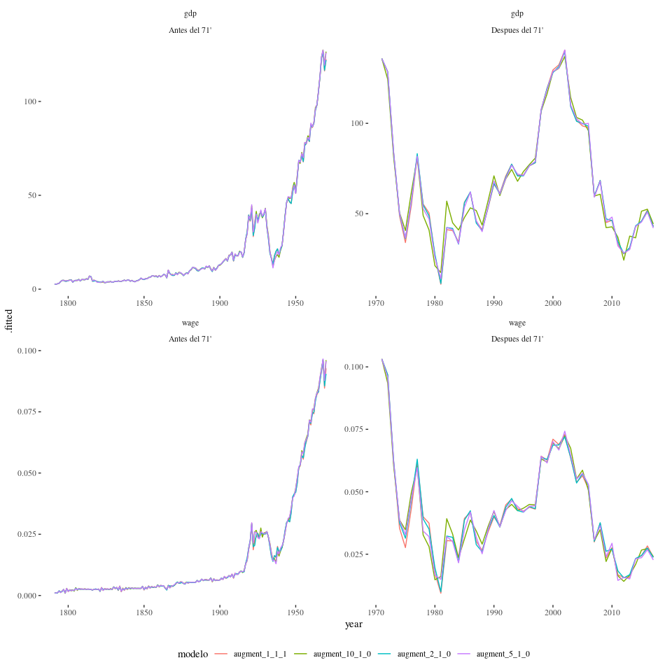

```r
nested_df %>%
  mutate(augment_2_1_0 = map(fitted_arima_2_1_0,sw_augment),
         augment_5_1_0 = map(fitted_arima_5_1_0,sw_augment),
         augment_10_1_0 = map(fitted_arima_10_1_0,sw_augment),
         augment_1_1_1 = map(fitted_arima_1_1_1,sw_augment)) %>%
  select(tipo, group, data, augment_2_1_0, augment_5_1_0,  augment_10_1_0, augment_1_1_1) %>%
   gather(modelo, augment, 4:ncol(.)) %>%
  unnest() %>%
  ggplot(.,aes(year,.fitted, color = modelo))+
  geom_line()+
  facet_wrap(tipo~group, scales = "free")+
  theme_tufte()+
  theme(legend.position = "bottom")
```

¯\*(ツ)*/¯

## Auto.Arima

```r
nested_df <- df %>%
  group_by(tipo,group) %>%
  nest()
fit_auto_arima <- function(df){
  auto.arima(df$value)
}
nested_df <- nested_df %>%
  group_by(tipo, group) %>%
  mutate(fitted_auto_arima = map(data,fit_auto_arima),
         tidy = map(fitted_auto_arima,sw_tidy),
         glance = map(fitted_auto_arima,sw_glance),
         augment = map(fitted_auto_arima,sw_augment))
```

```r
nested_df %>%
unnest(glance, .drop=TRUE) %>%
  select(tipo, group, model.desc, sigma,RMSE) %>%
  xtable::xtable(.)
```

```
% latex table generated in R 3.5.1 by xtable 1.8-3 package
% Mon Oct  8 11:02:23 2018
\begin{table}[ht]
\centering
\begin{tabular}{rlllrr}
  \hline
 & tipo & group & model.desc & sigma & RMSE \\
  \hline
1 & wage & Antes del 71' & ARIMA(2,2,1) & 0.00 & 0.00 \\
  2 & wage & Despues del 71' & ARIMA(1,0,2) with non-zero mean & 0.01 & 0.01 \\
  3 & gdp & Antes del 71' & ARIMA(0,2,2) & 2.48 & 2.45 \\
  4 & gdp & Despues del 71' & ARIMA(2,0,0) with non-zero mean & 9.59 & 9.27 \\
   \hline
\end{tabular}
\end{table}
```

Antes del 71’ para ambas variables el mejor modelo es un proceso integrado de orden dos, mientras que para las series después del 71’ el mejor modelo no es integrado, pero tiene una media distinta a cero.

Además, antes de 71’ los modelos tienen menor desvío y RMSE

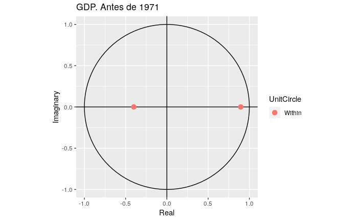

```r
nested_df %>%
  filter(tipo == "gdp", group=="Antes del 71'") %$%
  autoplot(fitted_auto_arima[[1]])+
  labs(title = "GDP. Antes de 1971")
```

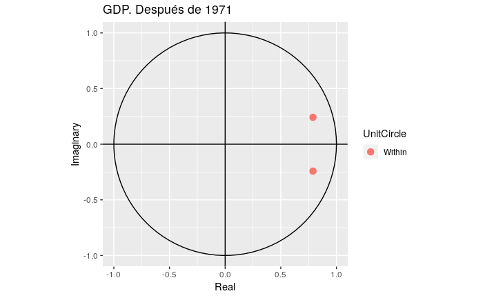

```r
nested_df %>%
  filter(tipo == "gdp", group=="Despues del 71'") %$%
  autoplot(fitted_auto_arima[[1]])+
  labs(title = "GDP. Después de 1971")
```

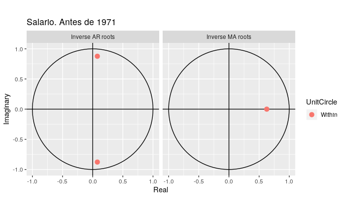

```r
nested_df %>%
  filter(tipo == "wage", group=="Antes del 71'") %$%
  autoplot(fitted_auto_arima[[1]])+
  labs(title = "Salario. Antes de 1971")
```

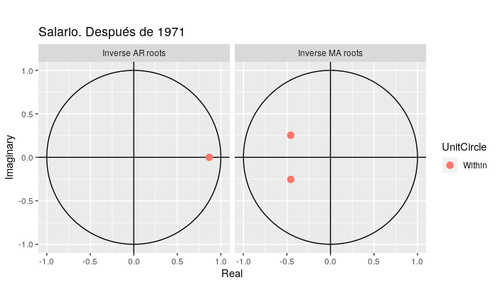

```r
nested_df %>%
  filter(tipo == "wage", group=="Despues del 71'") %$%
  autoplot(fitted_auto_arima[[1]])+
  labs(title = "Salario. Después de 1971")
```

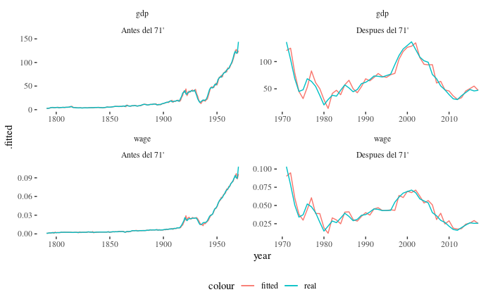

```r
nested_df %>%
  select(tipo, group, data, augment) %>%
  unnest() %>%
  ggplot(.,aes(year))+
  geom_line(aes(y=.fitted,color="fitted"))+
  geom_line(aes(y=value,color="real"))+
  facet_wrap(tipo~group, scales = "free")+
  theme_tufte()+
  theme(legend.position = "bottom")
ggsave("plots/arima_groups.png", dpi = 300)
```

El modelo funciona mejor para antes de 71’ que para después.

Sin quebrar las series:

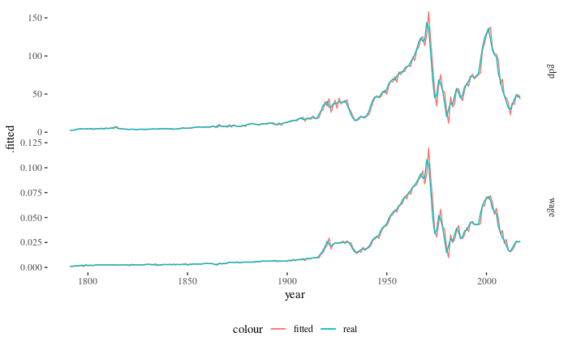

```r
nested_df <- df %>%
  select(-group) %>%
  group_by(tipo) %>%
  nest()
nested_df <- nested_df %>%
  group_by(tipo) %>%
  mutate(fitted_auto_arima = map(data,fit_auto_arima),
         tidy = map(fitted_auto_arima,sw_tidy),
         glance = map(fitted_auto_arima,sw_glance),
         augment = map(fitted_auto_arima,sw_augment))
nested_df %>%
  select(tipo, data, augment) %>%
  unnest() %>%
  ggplot(.,aes(year))+
  geom_line(aes(y=.fitted,color="fitted"))+
  geom_line(aes(y=value,color="real"))+
  facet_grid(tipo~., scales = "free")+
  theme_tufte()+
  theme(legend.position = "bottom")
ggsave("plots/arima_tot.png", dpi = 300)
```

```r
nested_df %>%
  unnest(glance)
```

| tipo | data | fitted_auto_arima | tidy | augment | model.desc | sigma | logLik | AIC | BIC | ME | RMSE | MAE | MPE | MAPE | MASE | ACF1 |
| --- | --- | --- | --- | --- | --- | --- | --- | --- | --- | --- | --- | --- | --- | --- | --- | --- |
| wage |  |  |  |  | ARIMA(1,1,2) | 0.003264216 | 973.9230 | -1939.846 | -1926.164 | 5.722077e-05 | 0.003235328 | 0.001663312 | 0.5260315 | 9.748241 | 0.8538477 | 0.006014935 |
| gdp |  |  |  |  | ARIMA(1,1,2) | 4.858568945 | -677.0641 | 1362.128 | 1375.810 | 1.143108e-01 | 4.815571914 | 2.664725430 | 0.5824430 | 8.606391 | 0.8438733 | -0.022278731 |

El RMSE queda en el medio entre ambos. No pareciera mejorar la predicción general separando.